# Bayesian data analysis & cognitive modeling

\[ \definecolor{firebrick}{RGB}{178,34,34} \newcommand{\red}[1]{{\color{firebrick}{#1}}} \] \[ \definecolor{mygray}{RGB}{178,34,34} \newcommand{\mygray}[1]{{\color{mygray}{#1}}} \] \[ \newcommand{\set}[1]{\{#1\}} \] \[ \newcommand{\tuple}[1]{\langle#1\rangle} \] \[\newcommand{\States}{{T}}\] \[\newcommand{\state}{{t}}\] \[\newcommand{\pow}[1]{{\mathcal{P}(#1)}}\]

## 3 pillars of BDA

## estimation

given model and data, which parameter values should we believe in?

\[\underbrace{P(\theta \, | \, D)}_{posterior} \propto \underbrace{P(\theta)}_{prior} \ \underbrace{P(D \, | \, \theta)}_{likelihood}\]

## model comparison

which of two models is more likely, given the data?

\[\underbrace{\frac{P(M_1 \mid D)}{P(M_2 \mid D)}}_{\text{posterior odds}} = \underbrace{\frac{P(D \mid M_1)}{P(D \mid M_2)}}_{\text{Bayes factor}} \ \underbrace{\frac{P(M_1)}{P(M_2)}}_{\text{prior odds}}\]

## prediction

which future observations do we expect (after seeing some data)?

prior predictive

\[ P(D) = \int P(\theta) \ P(D \mid \theta) \ \text{d}\theta \]

posterior predictive

\[ P(D \mid D') = \int P(\theta \mid D') \ P(D \mid \theta) \ \text{d}\theta \]

requires sampling distribution (more on this later)

special case: prior/posterior predictive \(p\)-value (model criticism)

## preliminaries

## summary

|  | standard | Bayes |
| --- | --- | --- |
| today's focus | Akaike's information criterion | Bayes factor |
| what counts as model to be compared? | likelihood function \(P(D \mid \theta)\) | likelihood \(P(D \mid \theta)\) + prior \(P(\theta)\) |
| from which point of view do we compare models? | ex post: after seeing the data | ex ante: before seeing the data |
| how to penalize model complexity? | count number of free parameters | implicitly weigh how effective a parameter is |
| are we guaranteed to select the true model in the end? | no | yes |
| hard to compute? | relatively easy | relatively hard |

## maximum likelihood

## forgetting data

- subjects each where asked to remember items (Murdoch 1961)
- recall rates `y` for 100 subjects after time `t` in seconds

```r
y = c(.94, .77, .40, .26, .24, .16)
t = c(  1,   3,   6,   9,  12,  18)
obs = y*100
```

example from Myung (2007), JoMP, tutorial on MLE

## forgetting models

recall probabilities for different times \(t\)

exponential model

\[P(t \ ; \ a, b) = a \exp (-bt)\]

\[\text{where } a,b>0 \]

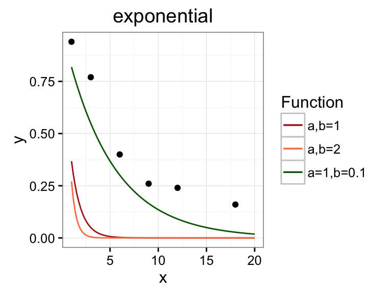

power model

\[P(t \ ; \ c, d) = ct^{-d}\]

\[\text{where } c,d>0 \]

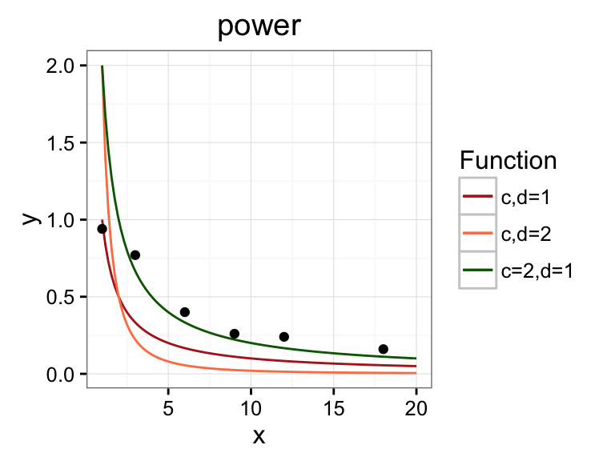

## negative log-likelihood

exponential

```r
nLL.exp <- function(w1,w2) {
  if (w1 < 0 | w2 < 0 |
      w1 > 20 | w2 > 20) {
    return(NA)
  }
  p = w1*exp(-w2*t)
  p[p <= 0.0] = 1.0e-5
  p[p >= 1.0] = 1-1.0e-5
  - sum(dbinom(x = obs, prob = p,
               size = 100, log = T))
}
show(nLL.exp(1,1))
```

```
## [1] 1092.446
```

power

```r
nLL.pow <- function(w1,w2) {
  if (w1 < 0 | w2 < 0 |
      w1 > 20 | w2 > 20) {
    return(NA)
  }
  p = w1*t^(-w2)
  p[p <= 0.0] = 1.0e-5
  p[p >= 1.0] = 1-1.0e-5
  - sum(dbinom(x = obs, prob = p,
               size = 100, log = T))
}
show(nLL.pow(1,1))
```

```
## [1] 142.1096
```

## MLE

```r
require('stats4')
bestExpo = mle(nLL.exp, start = list(w1=1,w2=1))
bestPow  = mle(nLL.pow, start = list(w1=1,w2=1))
MLEstimates = data.frame(model = rep(c("expo", "power"), each = 2),
                         parameter = c("a", "b", "c", "d"),
                         value = c(coef(bestExpo), coef(bestPow)))
knitr::kable(MLEstimates)
```

| model | parameter | value |
| --- | --- | --- |
| expo | a | 1.0701173 |
| expo | b | 0.1308300 |
| power | c | 0.9531186 |
| power | d | 0.4979311 |

## best fits visualization

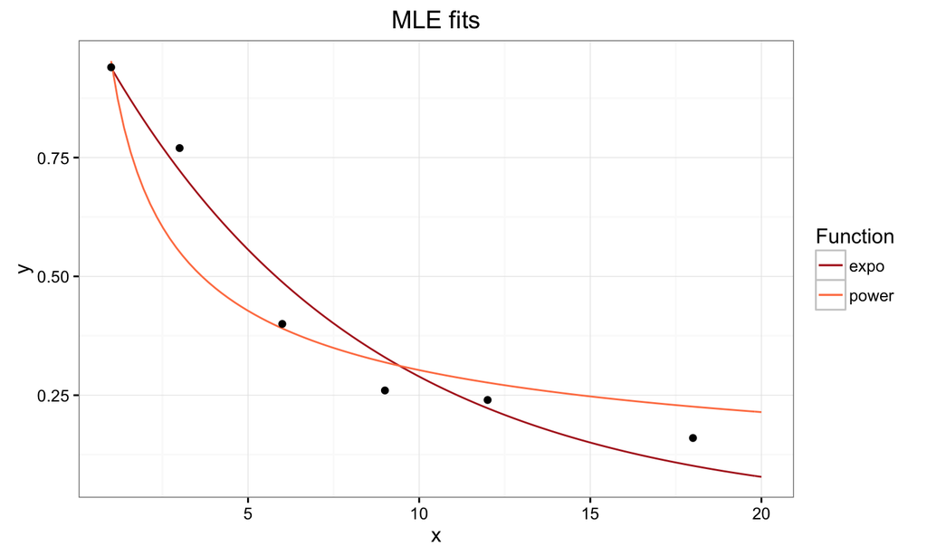

## model comparison

which model is better?

```r
predExp = expo(t,a,b)
predPow = power(t,c,d)
modelStats = data.frame(model = c("expo", "power"),
                        logLike = round(c(logLik(bestExpo), logLik(bestPow)),3),
                        pData = exp(c(logLik(bestExpo), logLik(bestPow))),
                        r = round(c(cor(predExp, y), cor(predPow,y)),3),
                        LSE = round(c( sum((predExp-y)^2), sum((predPow-y)^2)),3))
modelStats
```

```
##   model logLike        pData     r   LSE
## 1  expo -18.666 7.820887e-09 0.982 0.019
## 2 power -26.726 2.471738e-12 0.948 0.057
```

## Akaike information criterion

## Akaike information criterion

motivation

- model is better, the higher \(P(D \mid \hat{\theta})\)
  - where \(\hat{\theta} \in \arg \max_\theta P(D \mid \theta)\) is the maximum likelihood estimate
- model is worse, the more parameters it has
  - principle of parsimony (Ockham's razor)
- information theoretic notion:
  - amount of information lost when assuming data was generated with \(\hat{\theta}\)

definition

Let \(M\) be a model with \(k\) parameters, and \(D\) be some data:

\[\text{AIC}(M, D) = 2k - 2\ln P(D \mid \hat{\theta})\]

The smaller the AIC, the better the model.

## model comparison by AIC

```
##   model logLike        pData     r   LSE      AIC
## 1  expo -18.666 7.820887e-09 0.982 0.019 41.33294
## 2 power -26.726 2.471738e-12 0.948 0.057 57.45220
```

```r
show(AIC(bestExpo, bestPow))
```

```
##          df      AIC
## bestExpo  2 41.33294
## bestPow   2 57.45220
```

## concluding remarks

- given more and more data, repeated model selection by AIC does not guarantee ending up with the true model
- "model" for AICs is just likelihood; no prior
- discounting number of parameters, like AIC does, does not take effective strength of parameters into account
  - think: individual-level parameters harnessed by hierarchical population-level prior
- there are other information criteria that overcome some of these problems:
  - Bayesian information criterion
  - deviance information criterion

## Bayes factors

## Bayes factors

- take two models:
  - \(P(\theta_1 \mid M_1)\) and \(P(D \mid \theta_1, M_1)\)
  - \(P(\theta_2 \mid M_2)\) and \(P(D \mid \theta_2, M_2)\)
- ideally, we'd want to know the absolute probability of \(M_i\) given the data
  - but then we'd need to know set of all models (for normalization)
- alternatively, we take odds of models given the data:

\[\underbrace{\frac{P(M_1 \mid D)}{P(M_2 \mid D)}}_{\text{posterior odds}} = \underbrace{\frac{P(D \mid M_1)}{P(D \mid M_2)}}_{\text{Bayes factor}} \ \underbrace{\frac{P(M_1)}{P(M_2)}}_{\text{prior odds}}\]

The Bayes factor is the factor by which our prior odds are changed by the data.

## marginal likelihood

Bayes factor in favor of model \(M_1\)

\[\text{BF}(M_1 > M_2) = \frac{P(D \mid M_1)}{P(D \mid M_2)}\]

marginal likelihood of data under model \(M_i\)

\[P(D \mid M_i) = \int P(\theta_i \mid M_i) \ P(D \mid \theta_i, M_i) \text{ d}\theta_i\]

- we marginalize out parameters \(\theta_i\)
- this is a function of the prior and the likelihood

## how to interpret Bayes factors

| BF(M1 > M2) | interpretation |
| --- | --- |
| 1 | irrelevant data |
| 1 - 3 | hardly worth ink or breath |
| 3 - 6 | anecdotal |
| 6 - 10 | now we're talking: substantial |
| 10 - 30 | strong |
| 30 - 100 | very strong |
| 100 + | decisive (bye, bye \(M_2\)!) |

## how to caculate Bayes factors

1. get each model's marginal likelihood
   - grid approximation

     (today)
   - brute force clever math

     (next time)
   - by Monte Carlo sampling

     (next time)
2. get Bayes factor directly
   - Savage-Dickey method

     (today)
   - transdimensional MCMC

     (next time)

## grid approximation

## grid approximation

- consider discrete values for \(\theta\)
- compute evidence in terms of them
- works well for low-dimensional \(\theta\)

## example

```r
priorExpo = function(a, b){
  dunif(a, 0, 1.5) * dunif(b, 0, 1.5)
}
lhExpo = function(a, b){
  p = a*exp(-b*t)
  p[p <= 0.0] = 1.0e-5
  p[p >= 1.0] = 1-1.0e-5
  prod(dbinom(x = obs, prob = p, size = 100)) # no log!
}
```

```r
priorPow = function(c, d){
  dunif(c, 0, 1.5) * dunif(d, 0, 1.5)
}
lhPow = function(c, d){
  p = c*t^(-d)
  p[p <= 0.0] = 1.0e-5
  p[p >= 1.0] = 1-1.0e-5
  prod(dbinom(x = obs, prob = p, size = 100)) # no log!
}
```

## example

flat priors cancel out

```r
grid = seq(0.005, 1.495, by = 0.01)
margLikeExp = sum(sapply(grid, function(a)
      sum(sapply (grid, function(b) lhExpo(a,b)))) )
margLikePow = sum(sapply(grid, function(a)
      sum(sapply (grid, function(b) lhPow(a,b)))) )
show(as.numeric(margLikeExp / margLikePow))
```

```
## [1] 1221.392
```

overwhelming evidence in favor of the exponential model

## Savage-Dickey method

## Savage-Dickey method

let \(M_0\) be properly nested under \(M_1\) s.t. \(M_0\) fixes \(\theta_i = x_i, \dots, \theta_n = x_n\)

\[ \begin{align*} \text{BF}(M_0 > M_1) & = \frac{P(D \mid M_0)}{P(D \mid M_1)} \\ & = \frac{P(\theta_i = x_i, \dots, \theta_n = x_n \mid D, M_1)}{P(\theta_i = x_i, \dots, \theta_n = x_n \mid M_1)} \end{align*} \]

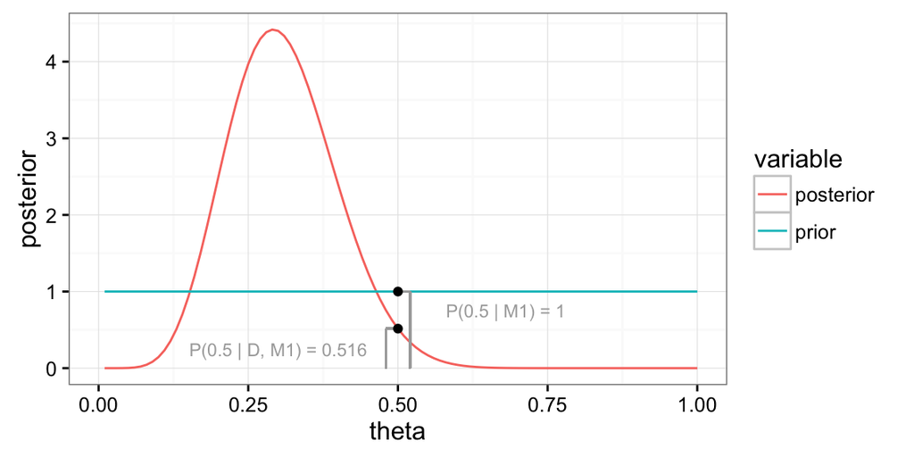

## proof

\[ \begin{align*} P(D \mid M_0) & = \int P(D \mid \psi, M_0) P(\psi \mid M_0) \ \text{d}\psi \\ & = \int P(D \mid \psi, \phi = \phi_0, M_1) P(\psi \mid \phi = \phi_0, M_1) \ \text{d}\psi\\ & = P(D \mid \phi = \phi_0, M_1) \ \ \ \ \ \ \text{(by Bayes rule)} \\ & = \frac{P(\phi = \phi_0 \mid D, M_1) P(D \mid M_1)}{P(\phi = \phi_0 \mid M_1)} \end{align*} \]

## fini

## summary

|  | standard | Bayes |
| --- | --- | --- |
| today's focus | Akaike's information criterion | Bayes factor |
| what counts as model to be compared? | likelihood function \(P(D \mid \theta)\) | likelihood \(P(D \mid \theta)\) + prior \(P(\theta)\) |
| from which point of view do we compare models? | ex post: after seeing the data | ex ante: before seeing the data |
| how to penalize model complexity? | count number of free parameters | implicitly weigh how effective a parameter is |
| are we guaranteed to select the true model in the end? | no | yes |
| hard to compute? | relatively easy | relatively hard |

## outlook

Friday

- boot camp on model comparison & Savage-Dickey

Tuesday

- more on Bayes factor computation & model comparison
  - Monte Carlo simulation to approximate marginal likelihood
  - transdimensional MCMC

## to prevent boredom

obligatory

- read Lee & Wagenmakers chapter 7

optional

- skim examples from Lee & Wagenmakers chapters 8 & 9